# W3cubDocs

/Matplotlib 3.1

# matplotlib.pyplot.bar

**`matplotlib.pyplot.bar(x, height, width=0.8, bottom=None, *, align='center', data=None, **kwargs)` [[source]](https://matplotlib.org/3.1.1/_modules/matplotlib/pyplot.html#bar)**

Make a bar plot.

The bars are positioned at *x* with the given *align*ment. Their dimensions are given by *width* and *height*. The vertical baseline is *bottom* (default 0).

Each of *x*, *height*, *width*, and *bottom* may either be a scalar applying to all bars, or it may be a sequence of length N providing a separate value for each bar.

Parameters:

**`x : sequence of scalars`**

The x coordinates of the bars. See also *align* for the alignment of the bars to the coordinates.

**`height : scalar or sequence of scalars`**

The height(s) of the bars.

**`width : scalar or array-like, optional`**

The width(s) of the bars (default: 0.8).

**`bottom : scalar or array-like, optional`**

The y coordinate(s) of the bars bases (default: 0).

**`align : {'center', 'edge'}, optional, default: 'center'`**

Alignment of the bars to the *x* coordinates:

- 'center': Center the base on the *x* positions.
- 'edge': Align the left edges of the bars with the *x* positions.

To align the bars on the right edge pass a negative *width* and `align='edge'`.

Returns:

**`container : BarContainer`**

Container with all the bars and optionally errorbars.

Other Parameters:

**`color : scalar or array-like, optional`**

The colors of the bar faces.

**`edgecolor : scalar or array-like, optional`**

The colors of the bar edges.

**`linewidth : scalar or array-like, optional`**

Width of the bar edge(s). If 0, don't draw edges.

**`tick_label : string or array-like, optional`**

The tick labels of the bars. Default: None (Use default numeric labels.)

**`xerr, yerr : scalar or array-like of shape(N,) or shape(2,N), optional`**

If not *None*, add horizontal / vertical errorbars to the bar tips. The values are +/- sizes relative to the data:

See [Different ways of specifying error bars](https://matplotlib.org/3.1.1/gallery/statistics/errorbar_features.html) for an example on the usage of `xerr` and `yerr`.

**`ecolor : scalar or array-like, optional, default: 'black'`**

The line color of the errorbars.

**`capsize : scalar, optional`**

The length of the error bar caps in points. Default: None, which will take the value from `rcParams["errorbar.capsize"]`.

**`error_kw : dict, optional`**

Dictionary of kwargs to be passed to the `errorbar` method. Values of *ecolor* or *capsize* defined here take precedence over the independent kwargs.

**`log : bool, optional, default: False`**

If *True*, set the y-axis to be log scale.

**`orientation : {'vertical', 'horizontal'}, optional`**

*This is for internal use only.* Please use `barh` for horizontal bar plots. Default: 'vertical'.

See also

**`barh`**

Plot a horizontal bar plot.

#### Notes

The optional arguments *color*, *edgecolor*, *linewidth*, *xerr*, and *yerr* can be either scalars or sequences of length equal to the number of bars. This enables you to use bar as the basis for stacked bar charts, or candlestick plots. Detail: *xerr* and *yerr* are passed directly to `errorbar()`, so they can also have shape 2xN for independent specification of lower and upper errors.

Other optional kwargs:

| Property | Description |
| --- | --- |
| `agg_filter` | a filter function, which takes a (m, n, 3) float array and a dpi value, and returns a (m, n, 3) array |
| `alpha` | float or None |
| `animated` | bool |
| `antialiased` or aa | unknown |
| `capstyle` | {'butt', 'round', 'projecting'} |
| `clip_box` | `Bbox` |
| `clip_on` | bool |
| `clip_path` | [(`Path`, `Transform`) \| `Patch` \| None] |
| `color` | color |
| `contains` | callable |
| `edgecolor` or ec | color or None or 'auto' |
| `facecolor` or fc | color or None |
| `figure` | `Figure` |
| `fill` | bool |
| `gid` | str |
| `hatch` | {'/', '\', '\|', '-', '+', 'x', 'o', 'O', '.', '*'} |
| `in_layout` | bool |
| `joinstyle` | {'miter', 'round', 'bevel'} |
| `label` | object |
| `linestyle` or ls | {'-', '--', '-.', ':', '', (offset, on-off-seq), ...} |
| `linewidth` or lw | float or None |
| `path_effects` | `AbstractPathEffect` |
| `picker` | None or bool or float or callable |
| `rasterized` | bool or None |
| `sketch_params` | (scale: float, length: float, randomness: float) |
| `snap` | bool or None |
| `transform` | `Transform` |
| `url` | str |
| `visible` | bool |
| `zorder` | float |

Note

In addition to the above described arguments, this function can take a **data** keyword argument. If such a **data** argument is given, the following arguments are replaced by **data[<arg>]**:

- All positional and all keyword arguments.

Objects passed as **data** must support item access (`data[<arg>]`) and membership test (`<arg> in data`).

## Examples using `matplotlib.pyplot.bar`

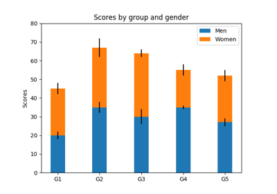

[Stacked Bar Graph](https://matplotlib.org/3.1.1/gallery/lines_bars_and_markers/bar_stacked.html#sphx-glr-gallery-lines-bars-and-markers-bar-stacked-py)

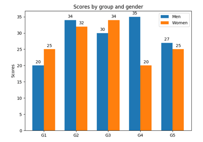

[Grouped bar chart with labels](https://matplotlib.org/3.1.1/gallery/lines_bars_and_markers/barchart.html#sphx-glr-gallery-lines-bars-and-markers-barchart-py)

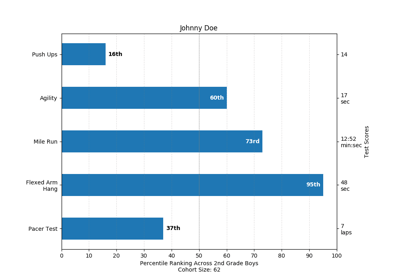

[Percentiles as horizontal bar chart](https://matplotlib.org/3.1.1/gallery/statistics/barchart_demo.html#sphx-glr-gallery-statistics-barchart-demo-py)

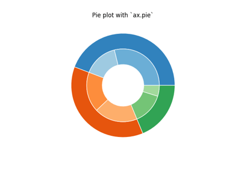

[Nested pie charts](https://matplotlib.org/3.1.1/gallery/pie_and_polar_charts/nested_pie.html#sphx-glr-gallery-pie-and-polar-charts-nested-pie-py)

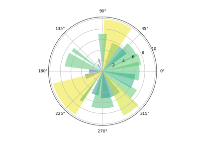

[Bar chart on polar axis](https://matplotlib.org/3.1.1/gallery/pie_and_polar_charts/polar_bar.html#sphx-glr-gallery-pie-and-polar-charts-polar-bar-py)

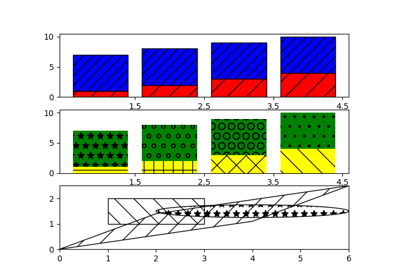

[Hatch Demo](https://matplotlib.org/3.1.1/gallery/shapes_and_collections/hatch_demo.html#sphx-glr-gallery-shapes-and-collections-hatch-demo-py)

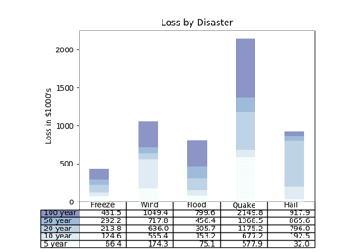

[Table Demo](https://matplotlib.org/3.1.1/gallery/misc/table_demo.html#sphx-glr-gallery-misc-table-demo-py)

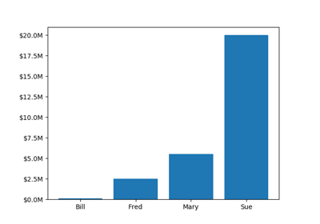

[Custom Ticker1](https://matplotlib.org/3.1.1/gallery/ticks_and_spines/custom_ticker1.html#sphx-glr-gallery-ticks-and-spines-custom-ticker1-py)

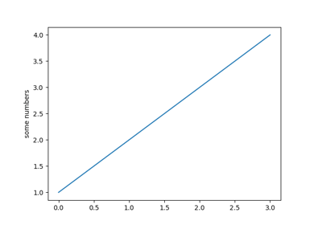

[Pyplot tutorial](https://matplotlib.org/3.1.1/tutorials/introductory/pyplot.html#sphx-glr-tutorials-introductory-pyplot-py)

© 2012–2018 Matplotlib Development Team. All rights reserved.  
Licensed under the Matplotlib License Agreement.  
https://matplotlib.org/3.1.1/api/_as_gen/matplotlib.pyplot.bar.html